# Overfitting and Model Tuning

# Overfitting and Model Tuning

author: Son Nguyen

# Reading Materials

- Max Kuhn. Chapter 4.

# Prediction Problem

Given data of $X = [X_1, X_2, ..., X_d]$ and $Y$. Find the relation between $X$ and $Y$.

# Prediction Problem - Examples

- One Input Variable $X$

| X | Y |
| --- | --- |
| 13 | 4.0 |
| 6 | 3.5 |
| 14 | 3 |
| 10 | 3.9 |
| 7 | 2.7 |
| 12 | 3.8 |
| 1 | 1.5 |

How are $X$ and $Y$ related?

# Prediction Problem - Examples

- Multiple Input Variables

| $X_1$ | $X_2$ | … | $X_{35}$ | $Y$ |
| --- | --- | --- | --- | --- |
| 1 | -1 | … | 2 | Tree |
| 2.1 | 0 | … | 6 | Not a Tree |
| 3 | 0 | … | 8 | Tree |

How are $X$ and $Y$ related?

# Prediction Problem

- If $Y$ is continous, we have a **regression** problem.
- If $Y$ is categorical, we have a **classification** problem.
- If $Y$ is binary, we have a **binary classification** problem.

# Prediction Problem - Examples

- This is a regression problem since $Y$ is continuous.

| X | Y |
| --- | --- |
| 13 | 4.0 |
| 6 | 3.5 |
| 14 | 3 |
| 10 | 3.9 |
| 7 | 2.7 |
| 12 | 3.8 |
| 1 | 1.5 |

# Prediction Problem - Examples

- This is a binary classification Problem since $Y$ is binary.

| $X_1$ | $X_2$ | … | $X_{35}$ | $Y$ |
| --- | --- | --- | --- | --- |
| 1 | -1 | … | 2 | Tree |
| 2.1 | 0 | … | 6 | Not a Tree |
| 3 | 0 | … | 8 | Tree |

# Overfitting

- Consider the data:

| X | Y |
| --- | --- |
| 13 | 4.0 |
| 6 | 3.5 |
| 14 | 3 |
| 10 | 3.9 |
| 7 | 2.7 |
| 12 | 3.8 |
| 1 | 1.5 |

- We will fit these data by polynomial model.
- In polynomial model, $Y$ is a polynomial function of $X$.

# Overfitting

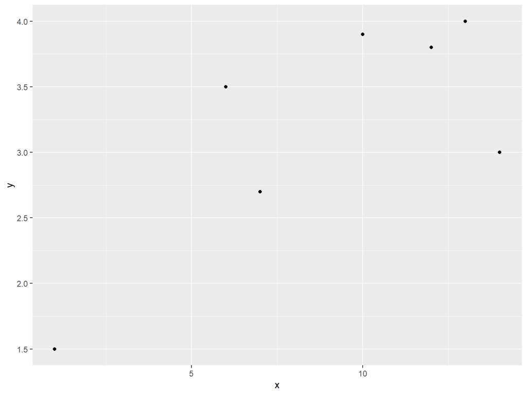

- We will fit these data by **polynomial model**.
- In polynomial model, $Y$ is a polynomial function of $X$.

# Overfitting - Polynomial Model

- In polynomial model, we need to specify the degree of the polynomial, $n$. Let try a few.
- If $n=1$, we have a familiar **linear model**.
- **Question: Does increasing $n$ resuls in a better model?**

# Overfitting - Polynomial Model

- $n=1$.

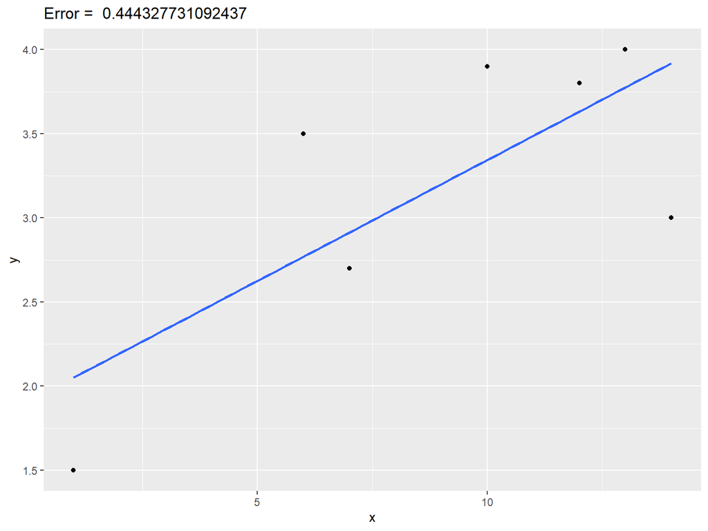

# Overfitting - Polynomial Model

- $n=2$.

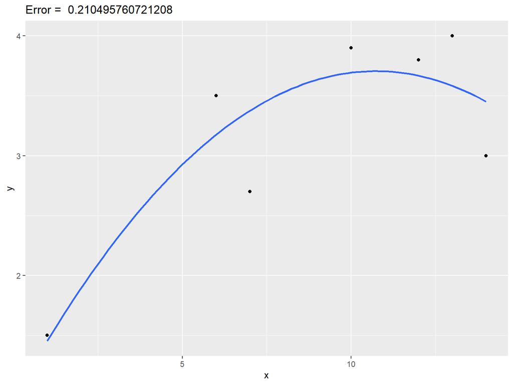

# Overfitting - Polynomial Model

- $n=3$.

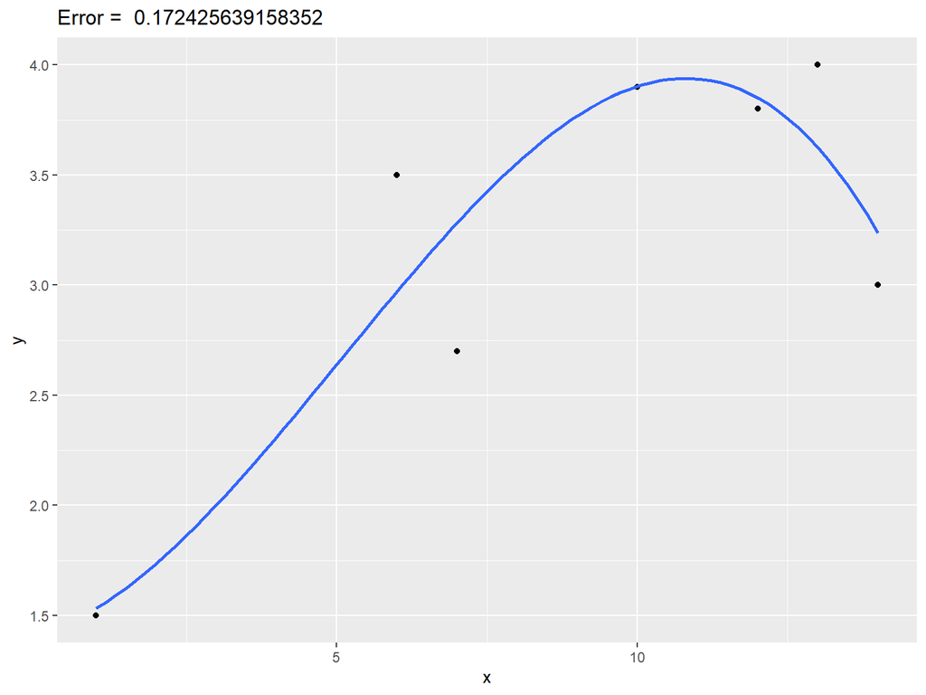

# Overfitting - Polynomial Model

- $n=4$.

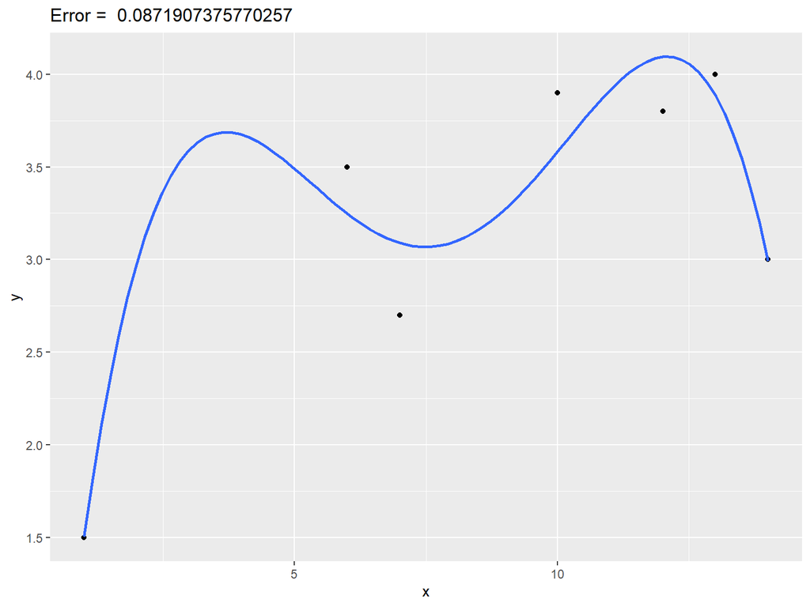

# Overfitting - Polynomial Model

- $n=5$.

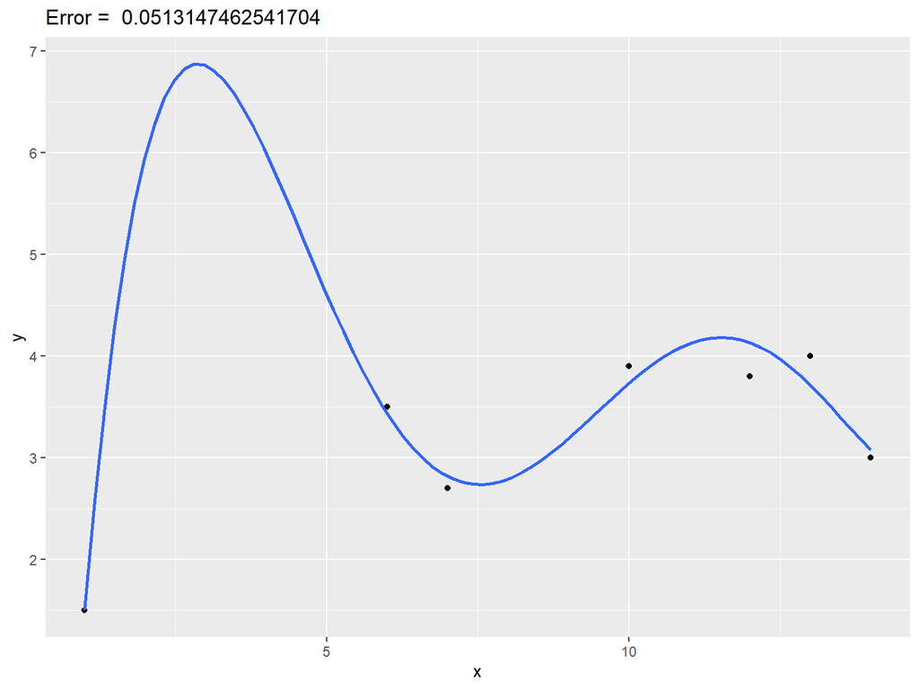

# Overfitting - Polynomial Model

- $n=6$.

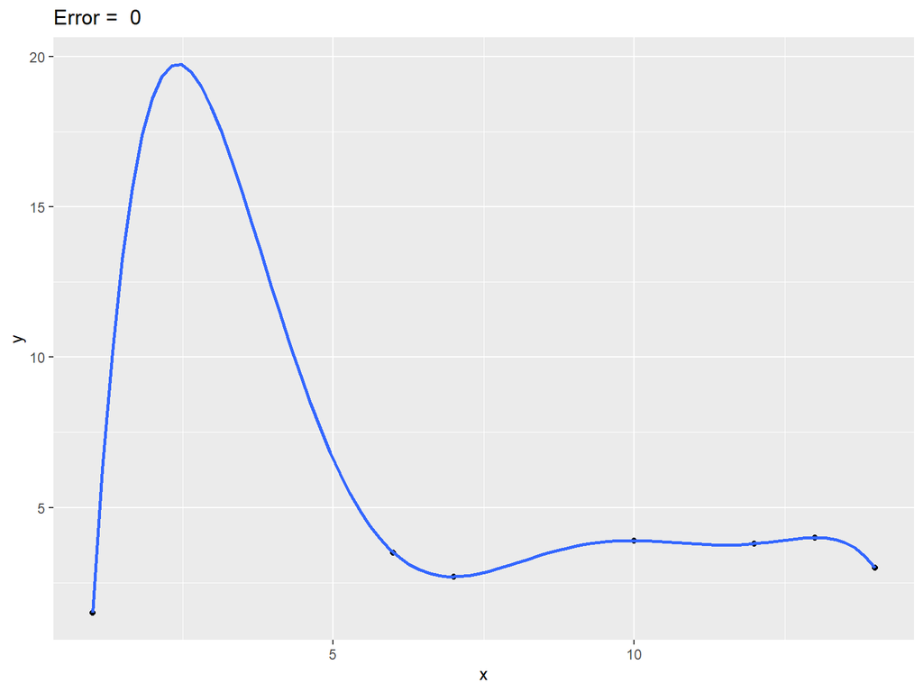

# Overfitting - Polynomial Model

- **Question**: What are the errors when $n>6$?

# Overfitting - Polynomial Model

- **Question**: What are the errors when $n>6$?
- **Answer**: The errors are all zeros. (There are actually many solutions for each degree greater than 6.)

# Overfitting - Polynomial Model

- **Question**: What is the best model?

# Overfitting - Polynomial Model

- **Question**: What is the best model?
- **Answer**: We do not know. We need a validation dataset to validate the models.

# Overfitting - Polynomial Model

- The errors we have seen are called **training errors**

# Overfitting - Polynomial Model

- Let’s validate these models with a validation dataset
- Validation Data

| X | Y |
| --- | --- |
| 5 | 2.6 |
| 7 | 3.5 |
| 9 | 4.0 |
| 6 | 3.7 |
| 12 | 5.0 |

# Overfitting - Polynomial Model

- $n=1$.

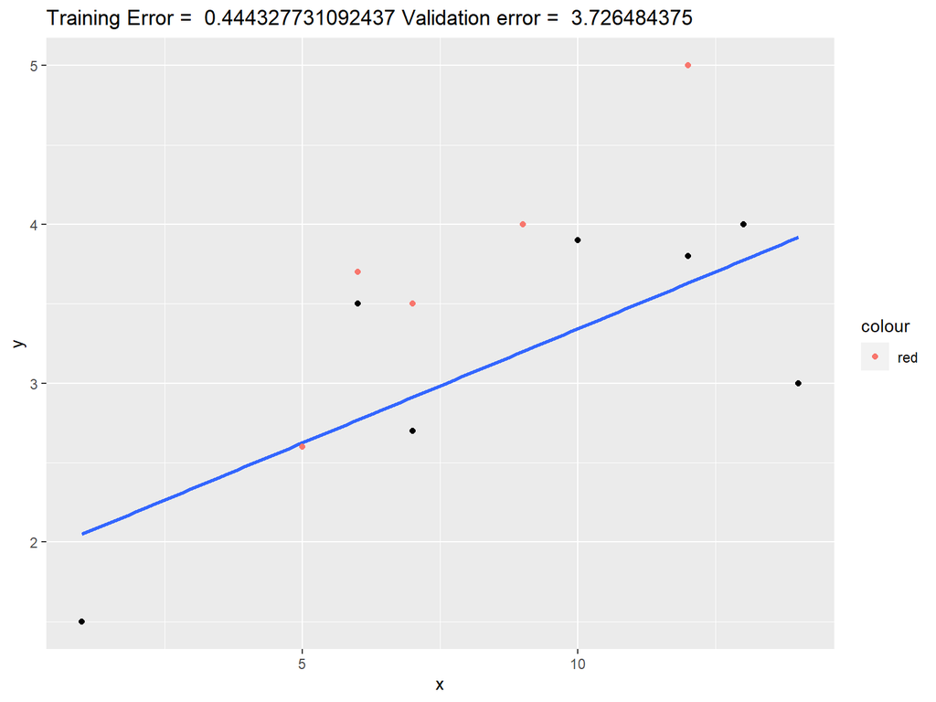

# Overfitting - Polynomial Model

- $n=2$.

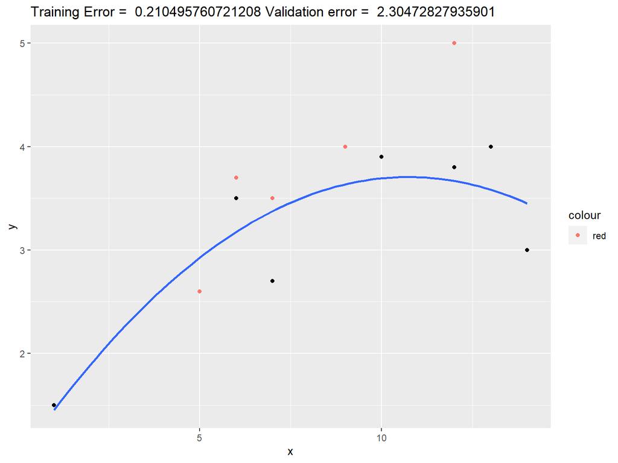

# Overfitting - Polynomial Model

- $n=3$.

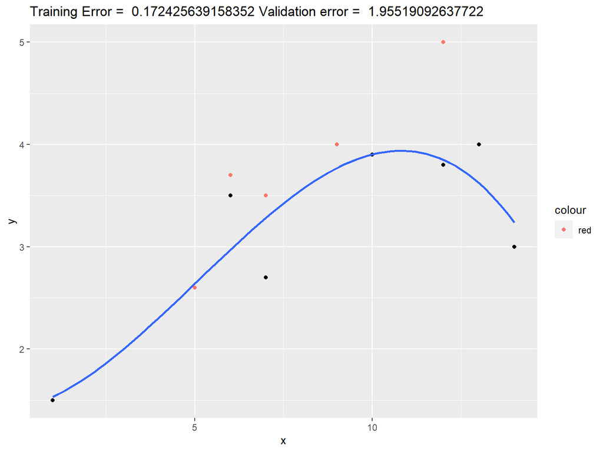

# Overfitting - Polynomial Model

- $n=4$.

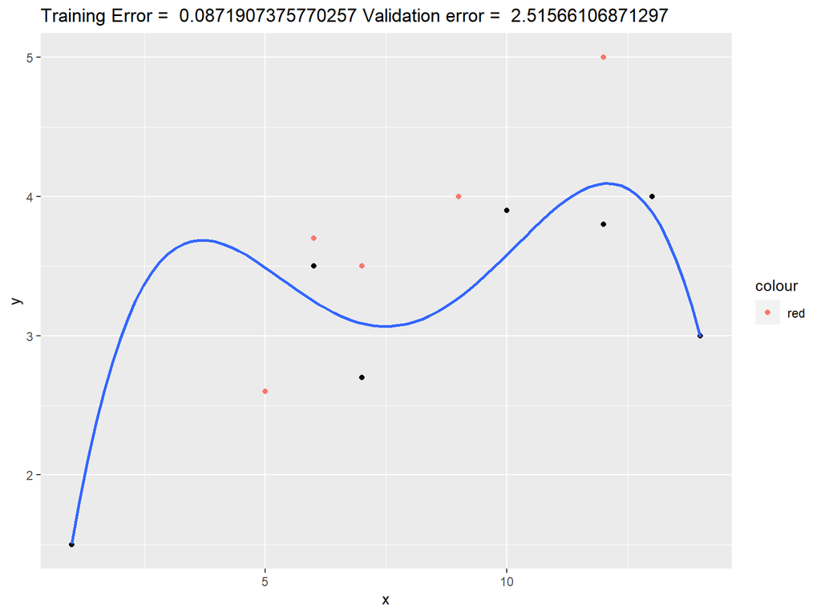

# Overfitting - Polynomial Model

- $n=5$.

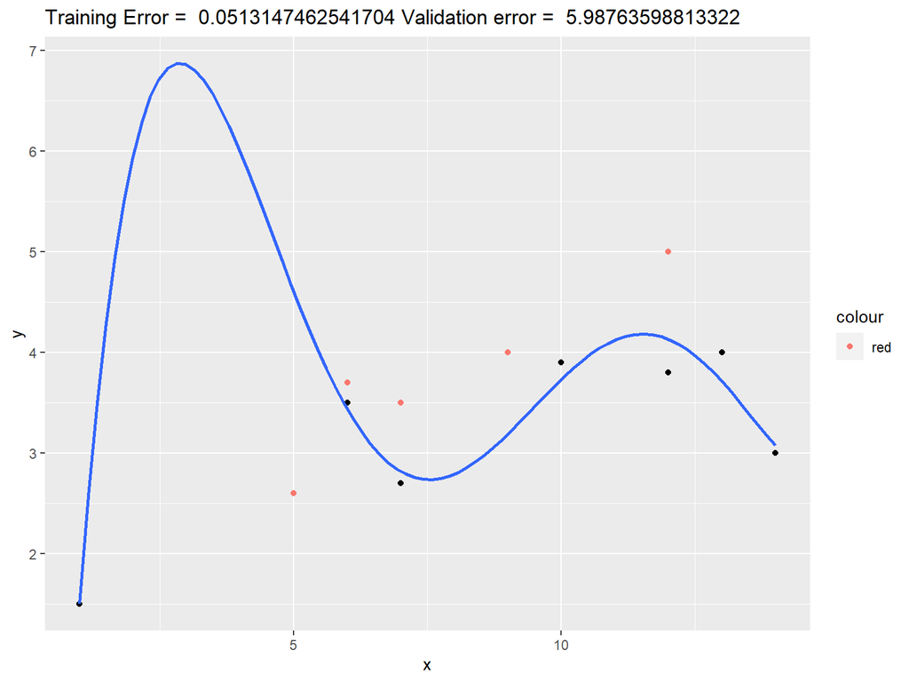

# Overfitting - Polynomial Model

- $n=6$.

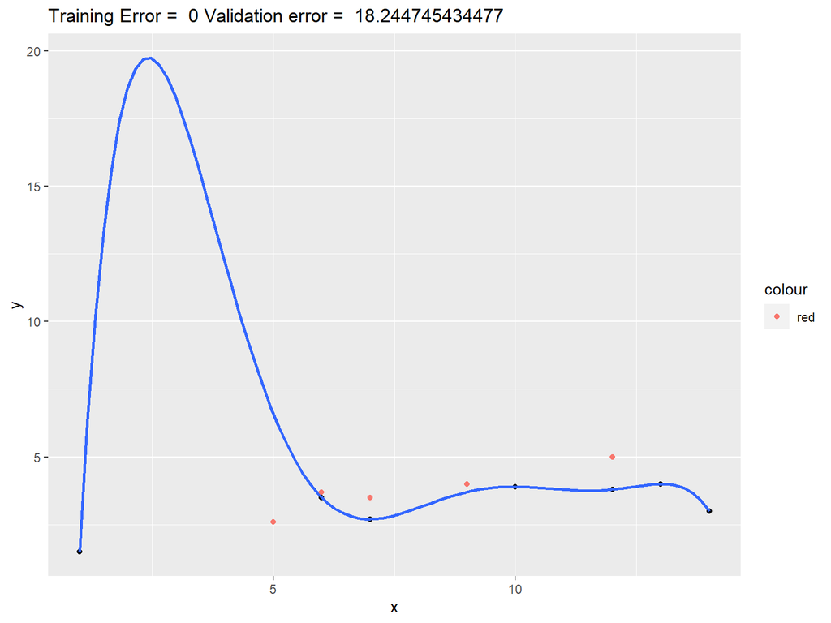

# Overfitting - Polynomial Model

- Training Error vs. Validation Error

|  | Training Error | Validation Error |
| --- | --- | --- |
| $n=1$ | 0.4443277 | 3.726484 |
| $n=2$ | 0.2104958 | 2.304728 |
| $n=3$ | 0.1724256 | **1.955191 (Best!)** |
| $n=4$ | 0.08719074 | 2.515661 |
| $n=5$ | 0.05131475 | 5.987636 |
| $n=6$ | 0 | 18.24475 |

# Overfitting - Polynomial Model

- Training Error vs. Validation Error

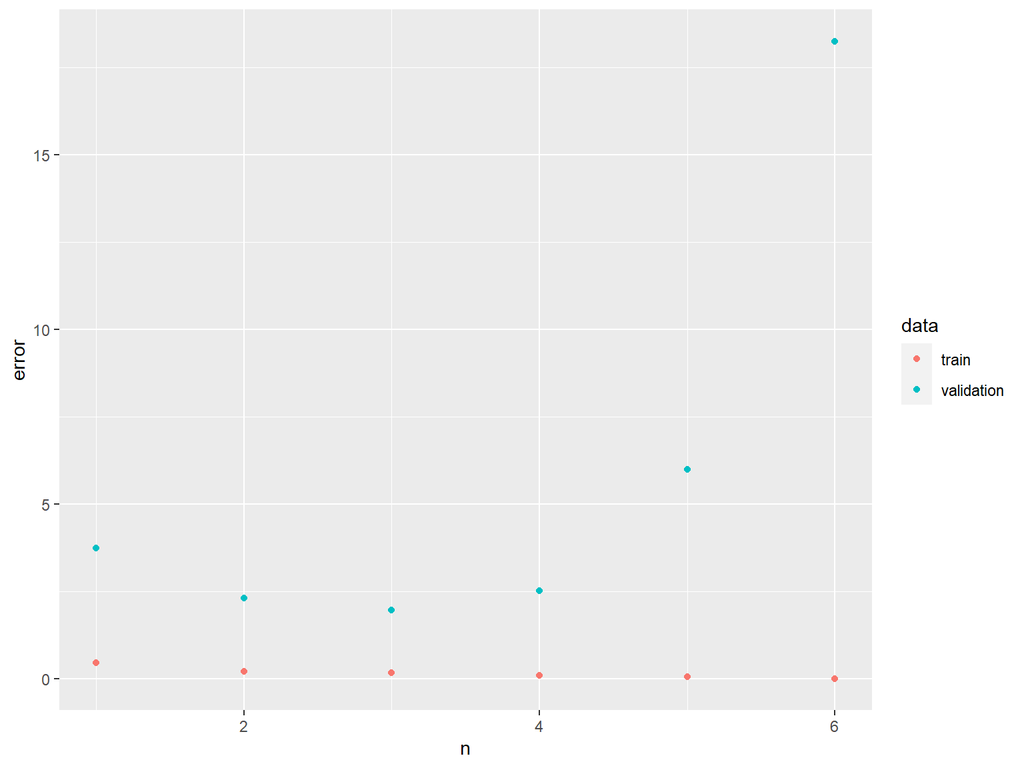

# Overfitting - Polynomial Model

- As the degree $n$ increases, the training errors decrease
- Model 6 ($n=6$) is the best (perfect) in training but the worst in validation.
- The best model is the model with the best (lowest) error in **validation data**.

# Overfitting in Regression

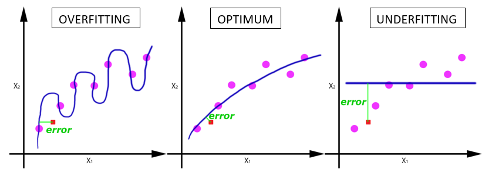

# Overfitting in Classification

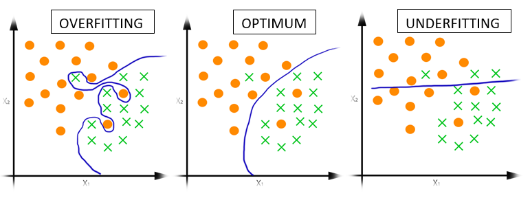

# Model Complexity/Capacity

- In polynomial models, the larger $n$, the more complex/capable the model.
- Model complexity can be measured by the number of parameters/unknown of the model.

# Model Complexity/Capacity

- Linear model:

$$y = ax+b$$

- **Question**: How many unknowns/parameters in linear model?

# Model Complexity/Capacity

- Linear model $(n=1)$:

$$y = ax+b$$

- **Question**: How many unknowns/parameters in linear model?
- **Answer**: Two unknowns/paramters: $a$ and $b$

# Model Complexity/Capacity

- Quadratic model $(n=2)$:

$$y = ax^2+bx+c$$

- Three unknowns: $a$, $b$, and $c$.
- Quadratic model has **more unknowns/parameters** then linear model. Thus, quadratic model is **more complex** than linear model

# Model Complexity/Capacity

- The mode complex the model, the easier it becomes overfitted!

# Model Complexity/Capacity

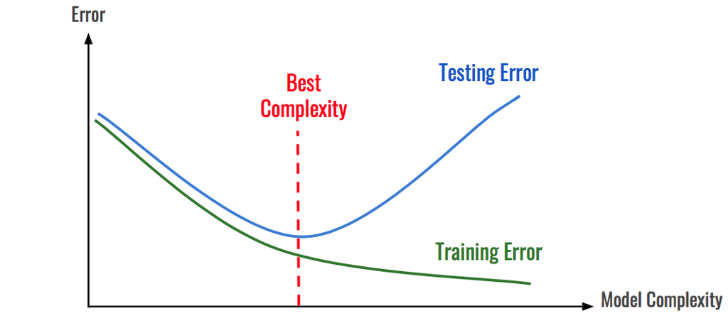

# Model Tuning

- We just “tuned” the the parameter $n$.
- The parameter $n$ is called **tuning parameter**, or **hyperparameter**

# Model Tuning

- Model tuning is the process of finding the **best** values for the tuning parameters of the model
- This is done through **trying out** many values for the tuning parameters then select the best values.

# Model Training

- Model training is the process of finding the unknown/parameters of the model
- **Example**: Training linear model $y= ax+b$ is to find $a$ and $b$ that best fit the data

# Model Training vs. Model Tuning

- Model training finds the **parameters**
- Model tuning finds **hyperparameters**

# Model vs. Family of Models

- The polynomial model is a **family** of models.
- Linear model is just **one** model
- A family of models has “tuning parameters”.
- A single model, say, linear model, does not have tuning parameter
- Some model has multiple tuning parameters.

# Data Splitting

- We need validation data for model tuning.
- **Question**: How can one of obtain validation data?

# Data Splitting

- We need validation data for model tuning.
- **Question**: How can one of obtain validation data?
- **Answer**: We do not use the entire data to train models. We use a portion of it for training and save data for validation and testing.

# Data Splitting: Train-Validation-Test

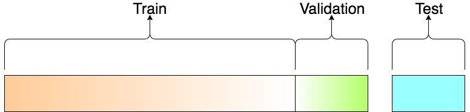

# k-folds Cross Validation

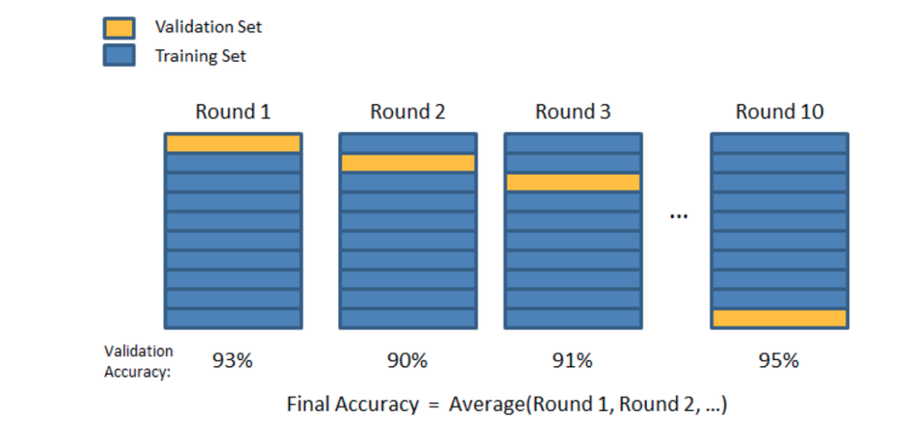

# k-folds Cross Validation

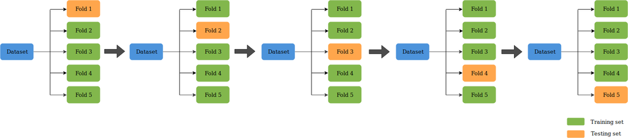

# k-folds Cross Validation and test

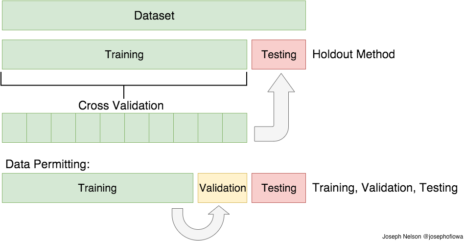